# Modulus of Permutations

### Information

Student: Vinny Sun

Graduate Mentor: Ngoc Huy Truong  
Faculty Mentor: Pietro Poggi-Corradini

Funded by:  
NSF DMS 2154032  
K-State Arts & Sciences Scholarship  
K-State Scholar Development and Undergraduate Research (SDUR) Award  
K-State Undergraduate Research Amplification Project (URAP) Grant

under NODE Group activities

### Items Read

Mathematics of Networks: Modulus Theory and Convex Optimization, Nathan Albin and Pietro Poggi-Corradini

Finding a Minimum Independent Dominating Set in a Permutation Graph, Mikhail J. Atallah

Maintenance of Configurations in the plane, Mark H. Overmars and Jan van Leeuwen

Combinatorics and Random Matrix Theory, Jinho Baik

### Permutations

An ordering of elements

Consider the permutation of $1,\dots,5$:

$$ \pi = 2\ 1\ 4\ 5\ 3 $$

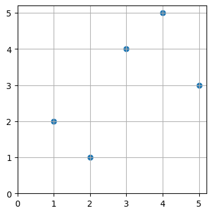

### Maximal Increasing Subsequence (MISS)

A subsequence of increasing elements in the permutation that cannot be extended

For $2\ 1\ 4\ 5\ 3$

$1\ 4\ 5$ is a MISS corresponding to indices $2\ 3\ 4$

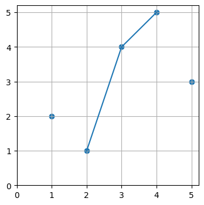

### Working towards the modulus

$\Gamma$ is a family of objects $\gamma$.

Then $\mathcal{N}$ is the *usage matrix* of objects in $\Gamma$.

For example, the entry for the previous MISS would be $\begin{bmatrix} 0 & 1 & 1 & 1 & 0 \end{bmatrix}$

We define $\rho \in \mathbb{R}_{+}^{N}$ (essentially node weights) and the $\rho$-length as $\ell_\rho(\gamma) := \sum_{v=1}^{N} \mathcal{N}(\gamma, v)\rho(v)$ (the "cost" of a MISS)

And admissibility: $\rho$ is admissible for $\Gamma$ if $\ell_\rho(\gamma) \geq 1 \: \forall \: \gamma \in \Gamma$

Now we can define the *p-Modulus* $\text{Mod}_p(\Gamma) = \inf\limits_{\rho \in \text{Adm}(\Gamma)} \sum_{v=1}^{N} \rho(v)^p$

### Two algorithms for computing modulus:

- Basic Algorithm
- Plus-1 Algorithm

Both of these algorithms need the *shortest_path* or the $\rho$-lightest MISS given some node weights

First, we generate all MISS

This is a subfamily of all up and right paths

```
[(1, 3), (1, 4), (1, 5), (2, 3), (2, 4), (2, 5), (3, 4)]
```

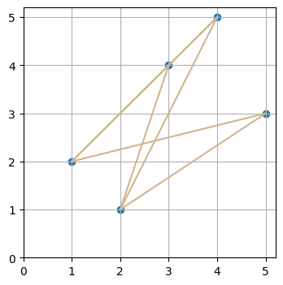

This is a subgraph formed by taking the union of all up and right paths

We just need to remove the "shortcuts"

For example:

[figure not shown]

```
[(1, 3), (1, 5), (2, 3), (2, 5), (3, 4)]
```

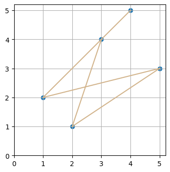

Then, we can label the sources and sinks:

[figure not shown]

and create directed edges for the up and right connections (nodes labeled by their index)

[figure not shown]

and then use NetworkX to find all paths from sources to sinks

$$\mathcal{N} = \begin{bmatrix} 1 & 0 & 0 & 0 & 1 \\ 0 & 1 & 0 & 0 & 1 \\ 1 & 0 & 1 & 1 & 0 \\ 0 & 1 & 1 & 1 & 0 \end{bmatrix}$$

However, this method is slow

We can instead use depth-first search to generate the usage matrix directly.

[figure not shown]

```
usage matrix from recursive function:
[[1. 0. 1. 1. 0.]
 [1. 0. 0. 0. 1.]
 [0. 1. 1. 1. 0.]
 [0. 1. 0. 0. 1.]]
```

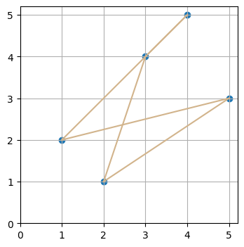

We can also do this with larger permutations

$$ \pi = 7\ 3\ 1\ 17\ 10\ 18\ 9\ 20\ 6\ 12\ 16\ 13\ 2\ 8\ 19\ 4\ 15\ 11\ 14\ 5 $$

```
71 rows in usage matrix
```

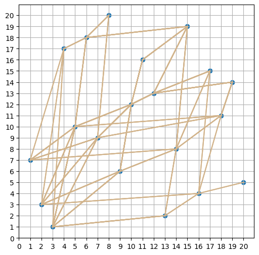

Finding the *shortest_path* / $\rho$-lightest MISS by augmenting dfs algorithm

[figure not shown]

If we don't need $\mathcal{N}$, we can also add pruning (greatly reduces runtime)

### Now we are ready to see the algorithms in action

Starting with the 1-modulus (node cut)

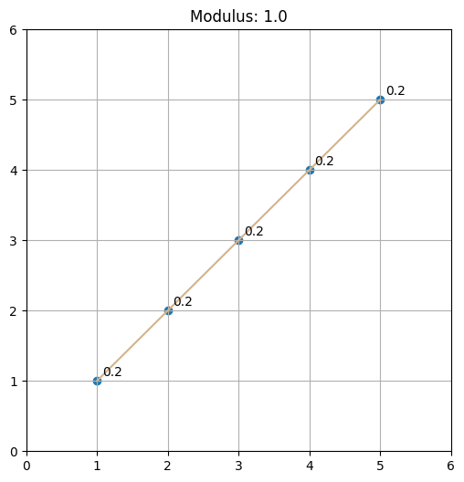

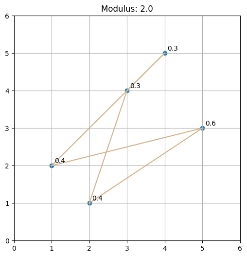

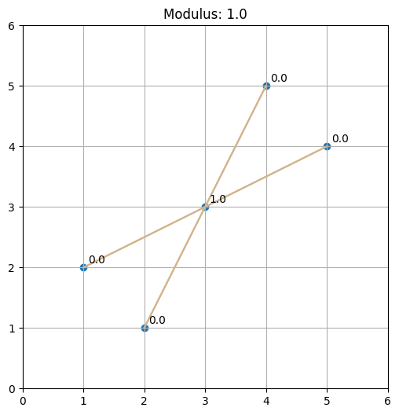

### Looking at both algorithms (2-modulus)

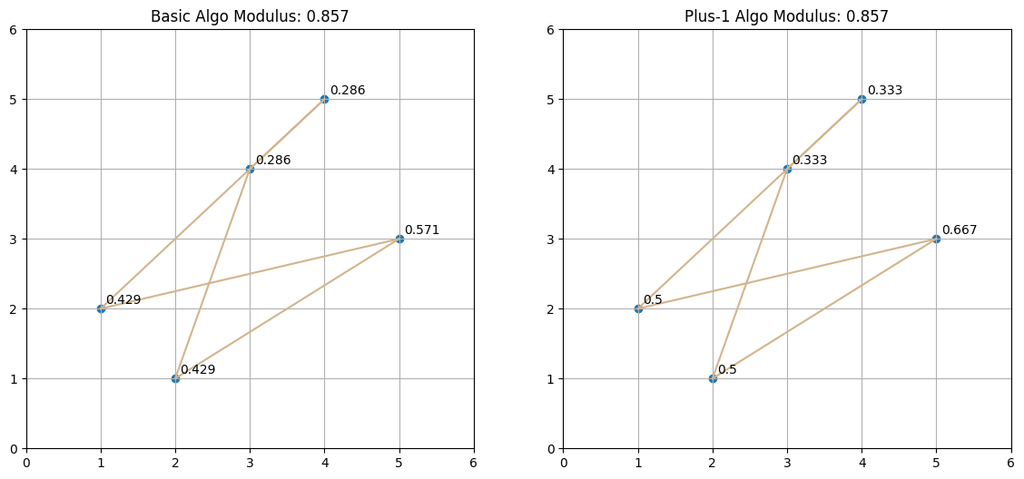

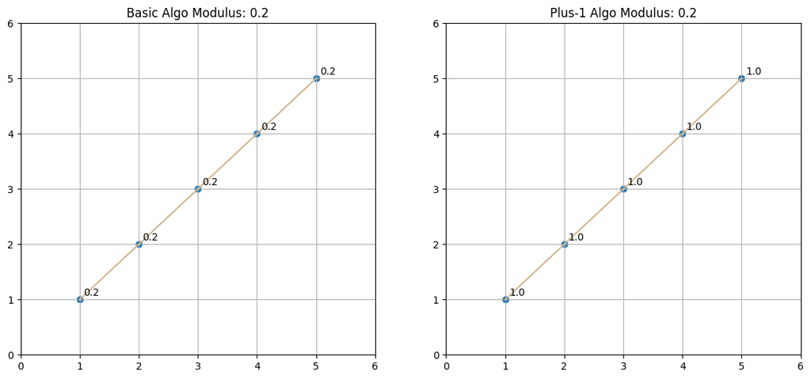

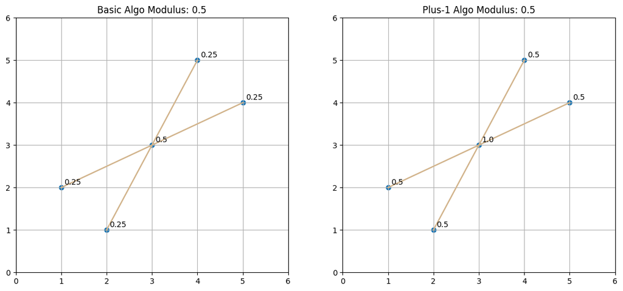

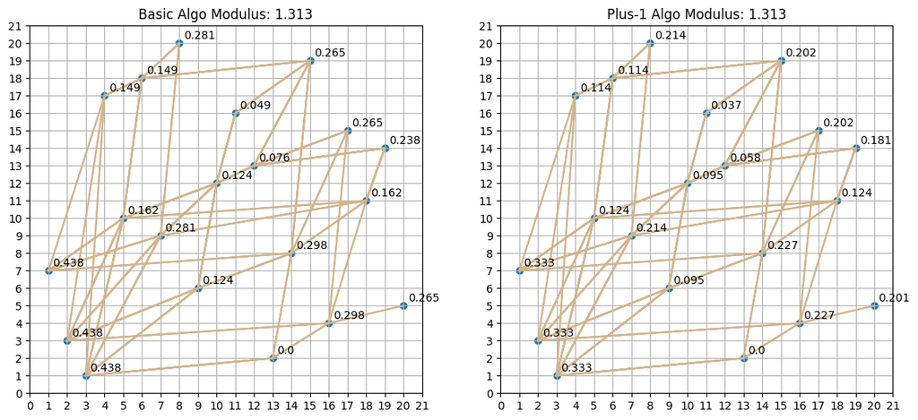

### Observation

The Basic Algorithm computes $\rho^*$ - the optimal density

The Plus-1 Algorithm computes $\eta^*$ where $\eta(v) = \mathbb{P}(v \in \text{MISS})$

$\eta^* = \frac{\rho^*}{\|\rho^*\|^2}$

$\text{Mod} = (\sum_{i \in \eta^*} \eta(i)^2)^{-1}$

### More on the 2-modulus

[figure not shown]

goes to 2 asymptotically?

### Dual

Every family has a dual family

Our family, $\Gamma$, of node-paths has a natural dual family, $\hat{\Gamma}$, of node-cuts

```
N:
 [[1. 0. 1. 1. 0.]
 [1. 0. 0. 0. 1.]
 [0. 1. 1. 1. 0.]
 [0. 1. 0. 0. 1.]]
```

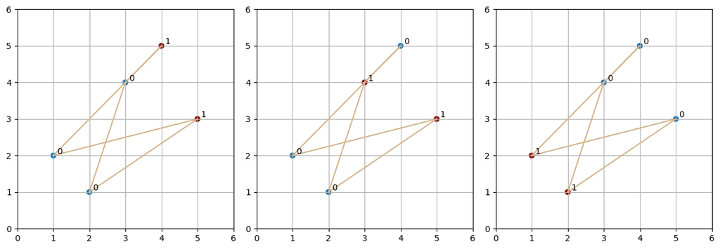

### Possible Usages

- MISS are commonly studied
- edge-modulus generalizes graph concepts

### Future Work

- Analyze and describe results in context of permutations
- Finish writing paper